# Project: Wrangle and Analyze WeRateDogs Twitter data

- Introduction
- Data Wrangling
- Data Gathering
- Data Assessing
- Data Cleaning
- Exploratory Data Analysis
- Conclusions

## Introduction

In this project, the tweet archive of Twitter user [@dog_rates](https://twitter.com/dog_rates), also known as WeRateDogs dataset will be wrangled. WeRateDogs is a Twitter account that rates people's dogs with a humorous comment about the dog. These ratings almost always have a denominator of 10. The numerators, though? Almost always greater than 10. 11/10, 12/10, 13/10, etc. Why? Because ["they're good dogs Brent."](http://knowyourmeme.com/memes/theyre-good-dogs-brent). WeRateDogs has over 9 million followers and has received international media coverage and popular posts are re-posted on Instagram and Facebook. Our goal is, wrangle WeRateDogs Twitter data to create interesting and "Wow!"-worthy analyses and visualizations.

**Questions**:

- Most tweeted dog breeds
- Most tweeted dog stages
- Most tweeted dog names
- Relationship between retweet and favorite counts
- Does Ratings associated with retweet and favorite counts?
- Which Dog breeds are popular(retweet,favorite) and received highest ratings?
- Which Dog stages are popular(retweet,favorite) and received highest ratings?

```python
# Import required packages
import pandas as pd
import numpy as np
import os
import requests
import tweepy
from tweepy import OAuthHandler
import json
from timeit import default_timer as timer
import re
import matplotlib.pyplot as plt
import seaborn as sns

# Magic word to visualize plots in the notebook
%matplotlib inline
```

## Data Wrangling

> The Data Wrangling process contains below steps
> - Data Gathering
> - Data Assessing
> - Data Cleaning

### Data Gathering

#### Enhanced Twitter Archive

Download `twitter_archive_enhanced.csv` from [Twitter archive](https://d17h27t6h515a5.cloudfront.net/topher/2017/August/59a4e958_twitter-archive-enhanced/twitter-archive-enhanced.csv) provided by Udacity which contains basic tweet data (tweet ID, timestamp, text, etc.)

```python
# Create data folder to store all data files
if not os.path.exists('data'):
    os.makedirs('data')
```

```python
# Get response from Twitter archive data url using requests library
archive_url = 'https://d17h27t6h515a5.cloudfront.net/topher/2017/August/59a4e958_twitter-archive-enhanced/twitter-archive-enhanced.csv'
response = requests.get(archive_url)

# Write Twitter archive data response into csv file
with open('data/twitter-archive-enhanced.csv', 'wb') as file:
    file.write(response.content)

# Read data from csv file and Load it into dataframe
archive = pd.read_csv('data/twitter-archive-enhanced.csv')
```

#### Image Predictions File

Download `image_predictions.tsv` from [image-predictions](https://d17h27t6h515a5.cloudfront.net/topher/2017/August/599fd2ad_image-predictions/image-predictions.tsv) provided by Udacity which contains table full of image predictions (the top three only) alongside each tweet ID, image URL, and the image number that corresponded to the most confident prediction

```python
# Get response from image-predictions url using requests library
img_pred_url = 'https://d17h27t6h515a5.cloudfront.net/topher/2017/August/599fd2ad_image-predictions/image-predictions.tsv'
response = requests.get(img_pred_url)

# Write image-predictions response into tsv file
with open('data/image-predictions.tsv', 'wb') as file:
    file.write(response.content)

# Read data from tsv file and Load it into dataframe
img_pred = pd.read_csv('data/image-predictions.tsv', sep = '\t')
```

#### Additional Data via the Twitter API

We will be using Tweepy to query Twitter's API for additional data beyond the data included in the WeRateDogs Twitter archive. This additional data will include retweet count and favorite count.

```python
# Query Twitter API for each tweet in the Twitter archive and save JSON in a text file
# These are hidden to comply with Twitter's API terms and conditions
consumer_key = '8MX5HZWGEWgrRt0vUN1Fesk0a'
consumer_secret = 'rhESwQh9x4a09YVl8CRnoV05lO7jP6HUds6Ty0GH5kTFVLtnS4'
access_token = '3147900582-zT3c5CEeWfFTDjRmmvCnKbyZfmRoPAqSAo5VxEg'
access_secret = 'P3VxOQSX6SfsZgXlNkLysExDpN8FCxx9MEGF0CLcfE5Gp'

auth = OAuthHandler(consumer_key, consumer_secret)
auth.set_access_token(access_token, access_secret)

api = tweepy.API(auth, wait_on_rate_limit=True, wait_on_rate_limit_notify=True)

tweet_ids = archive.tweet_id.values
len(tweet_ids)

# Query Twitter's API for JSON data for each tweet ID in the Twitter archive
count = 0
fails_dict = {}
start = timer()
tweet_api = []

# Save each tweet's returned JSON as a new line in a .txt file
with open('data/tweet_json.txt', 'w') as outfile:
    # This loop will likely take 20-30 minutes to run because of Twitter's rate limit
    for tweet_id in tweet_ids:
        count += 1
        print(str(count) + ": " + str(tweet_id))
        try:
            tweet = api.get_status(tweet_id, tweet_mode='extended')
            tweet_api.append({
                'tweet_id': tweet_id,
                'favorite_count': tweet._json['favorite_count'],
                'retweet_count': tweet._json['retweet_count']})
            print("Success")
            json.dump(tweet._json, outfile)
            outfile.write('\n')
        except tweepy.TweepError as e:
            print("Fail")
            fails_dict[tweet_id] = e
            pass
end = timer()

# Print the difference in start and end timers
print(end - start)

# Print failed Tweet IDs
print(fails_dict)
```

[output not shown]

[output cut: 1746 more lines]

[output not shown]

[output not shown]

[output not shown]

[output cut: 1745 more lines]

[output not shown]

[output not shown]

[output not shown]

[output cut: 1058 more lines]

[output not shown]

- Consider only the responses which are success

```python
# Store twitter API response content to dataframe for further analysis
tweet_api = pd.DataFrame(tweet_api)
tweet_api.to_csv('data/tweet_api_json.csv',encoding='utf-8', index=False)
```

```python
# Load data from the json csv
tweet_api = pd.read_csv('data/tweet_api_json.csv')
```

#### Visual Assessment

Each piece of gathered data assessed manually to identify **Quality** and **Tidiness issues** using Jupyter Notebook and other external applications like excel

```python
# Twitter Archive Data
archive
```

|  | tweet_id | in_reply_to_status_id | in_reply_to_user_id | timestamp | source | text | retweeted_status_id | retweeted_status_user_id | retweeted_status_timestamp | expanded_urls | rating_numerator | rating_denominator | name | doggo | floofer | pupper | puppo |
| --- | --- | --- | --- | --- | --- | --- | --- | --- | --- | --- | --- | --- | --- | --- | --- | --- | --- |
| 0 | 892420643555336193 | NaN | NaN | 2017-08-01 16:23:56 +0000 | <a href="http://twitter.com/download/iphone" r... | This is Phineas. He's a mystical boy. Only eve... | NaN | NaN | NaN | https://twitter.com/dog_rates/status/892420643... | 13 | 10 | Phineas | None | None | None | None |
| 1 | 892177421306343426 | NaN | NaN | 2017-08-01 00:17:27 +0000 | <a href="http://twitter.com/download/iphone" r... | This is Tilly. She's just checking pup on you.... | NaN | NaN | NaN | https://twitter.com/dog_rates/status/892177421... | 13 | 10 | Tilly | None | None | None | None |
| 2 | 891815181378084864 | NaN | NaN | 2017-07-31 00:18:03 +0000 | <a href="http://twitter.com/download/iphone" r... | This is Archie. He is a rare Norwegian Pouncin... | NaN | NaN | NaN | https://twitter.com/dog_rates/status/891815181... | 12 | 10 | Archie | None | None | None | None |
| 3 | 891689557279858688 | NaN | NaN | 2017-07-30 15:58:51 +0000 | <a href="http://twitter.com/download/iphone" r... | This is Darla. She commenced a snooze mid meal... | NaN | NaN | NaN | https://twitter.com/dog_rates/status/891689557... | 13 | 10 | Darla | None | None | None | None |
| 4 | 891327558926688256 | NaN | NaN | 2017-07-29 16:00:24 +0000 | <a href="http://twitter.com/download/iphone" r... | This is Franklin. He would like you to stop ca... | NaN | NaN | NaN | https://twitter.com/dog_rates/status/891327558... | 12 | 10 | Franklin | None | None | None | None |
| ... | ... | ... | ... | ... | ... | ... | ... | ... | ... | ... | ... | ... | ... | ... | ... | ... | ... |
| 2351 | 666049248165822465 | NaN | NaN | 2015-11-16 00:24:50 +0000 | <a href="http://twitter.com/download/iphone" r... | Here we have a 1949 1st generation vulpix. Enj... | NaN | NaN | NaN | https://twitter.com/dog_rates/status/666049248... | 5 | 10 | None | None | None | None | None |
| 2352 | 666044226329800704 | NaN | NaN | 2015-11-16 00:04:52 +0000 | <a href="http://twitter.com/download/iphone" r... | This is a purebred Piers Morgan. Loves to Netf... | NaN | NaN | NaN | https://twitter.com/dog_rates/status/666044226... | 6 | 10 | a | None | None | None | None |
| 2353 | 666033412701032449 | NaN | NaN | 2015-11-15 23:21:54 +0000 | <a href="http://twitter.com/download/iphone" r... | Here is a very happy pup. Big fan of well-main... | NaN | NaN | NaN | https://twitter.com/dog_rates/status/666033412... | 9 | 10 | a | None | None | None | None |
| 2354 | 666029285002620928 | NaN | NaN | 2015-11-15 23:05:30 +0000 | <a href="http://twitter.com/download/iphone" r... | This is a western brown Mitsubishi terrier. Up... | NaN | NaN | NaN | https://twitter.com/dog_rates/status/666029285... | 7 | 10 | a | None | None | None | None |
| 2355 | 666020888022790149 | NaN | NaN | 2015-11-15 22:32:08 +0000 | <a href="http://twitter.com/download/iphone" r... | Here we have a Japanese Irish Setter. Lost eye... | NaN | NaN | NaN | https://twitter.com/dog_rates/status/666020888... | 8 | 10 | None | None | None | None | None |

2356 rows × 17 columns

> - Null values in multiple columns
> - Reply and Retweet columns are present. **We only want original ratings (no retweets) that have images**
> - Rating numerator and denominator has strange values
> - Individual columns for dog stages
> - *&amp ;* present instead of **&** symbol in tweet text
> - Url present in both tweet `text` and `expanded_urls` which are same.

```python
# Image Predictions Data
img_pred
```

|  | tweet_id | jpg_url | img_num | p1 | p1_conf | p1_dog | p2 | p2_conf | p2_dog | p3 | p3_conf | p3_dog |
| --- | --- | --- | --- | --- | --- | --- | --- | --- | --- | --- | --- | --- |
| 0 | 666020888022790149 | https://pbs.twimg.com/media/CT4udn0WwAA0aMy.jpg | 1 | Welsh_springer_spaniel | 0.465074 | True | collie | 0.156665 | True | Shetland_sheepdog | 0.061428 | True |
| 1 | 666029285002620928 | https://pbs.twimg.com/media/CT42GRgUYAA5iDo.jpg | 1 | redbone | 0.506826 | True | miniature_pinscher | 0.074192 | True | Rhodesian_ridgeback | 0.072010 | True |
| 2 | 666033412701032449 | https://pbs.twimg.com/media/CT4521TWwAEvMyu.jpg | 1 | German_shepherd | 0.596461 | True | malinois | 0.138584 | True | bloodhound | 0.116197 | True |
| 3 | 666044226329800704 | https://pbs.twimg.com/media/CT5Dr8HUEAA-lEu.jpg | 1 | Rhodesian_ridgeback | 0.408143 | True | redbone | 0.360687 | True | miniature_pinscher | 0.222752 | True |
| 4 | 666049248165822465 | https://pbs.twimg.com/media/CT5IQmsXIAAKY4A.jpg | 1 | miniature_pinscher | 0.560311 | True | Rottweiler | 0.243682 | True | Doberman | 0.154629 | True |
| ... | ... | ... | ... | ... | ... | ... | ... | ... | ... | ... | ... | ... |
| 2070 | 891327558926688256 | https://pbs.twimg.com/media/DF6hr6BUMAAzZgT.jpg | 2 | basset | 0.555712 | True | English_springer | 0.225770 | True | German_short-haired_pointer | 0.175219 | True |
| 2071 | 891689557279858688 | https://pbs.twimg.com/media/DF_q7IAWsAEuuN8.jpg | 1 | paper_towel | 0.170278 | False | Labrador_retriever | 0.168086 | True | spatula | 0.040836 | False |
| 2072 | 891815181378084864 | https://pbs.twimg.com/media/DGBdLU1WsAANxJ9.jpg | 1 | Chihuahua | 0.716012 | True | malamute | 0.078253 | True | kelpie | 0.031379 | True |
| 2073 | 892177421306343426 | https://pbs.twimg.com/media/DGGmoV4XsAAUL6n.jpg | 1 | Chihuahua | 0.323581 | True | Pekinese | 0.090647 | True | papillon | 0.068957 | True |
| 2074 | 892420643555336193 | https://pbs.twimg.com/media/DGKD1-bXoAAIAUK.jpg | 1 | orange | 0.097049 | False | bagel | 0.085851 | False | banana | 0.076110 | False |

2075 rows × 12 columns

> - Contains three set of image predictions including **False** predictions
> - Predicted dog names contains difference kinds of casing. E.g: German_shepherd, redbone
> - Also, contains underscore and hyphen characters in names

```python
# Twitter API Data
tweet_api
```

|  | tweet_id | favorite_count | retweet_count |
| --- | --- | --- | --- |
| 0 | 892420643555336193 | 34559 | 7199 |
| 1 | 892177421306343426 | 29964 | 5407 |
| 2 | 891815181378084864 | 22540 | 3572 |
| 3 | 891689557279858688 | 37788 | 7416 |
| 4 | 891327558926688256 | 36089 | 7963 |
| ... | ... | ... | ... |
| 2323 | 666049248165822465 | 92 | 37 |
| 2324 | 666044226329800704 | 252 | 118 |
| 2325 | 666033412701032449 | 103 | 37 |
| 2326 | 666029285002620928 | 116 | 40 |
| 2327 | 666020888022790149 | 2325 | 436 |

2328 rows × 3 columns

#### Programmatic Assessment

Assessing data using pandas functions and methods

#### Archive

```python
# Brief summary of DataFrame to check missing or possibly errant data
archive.info()
```

```
<class 'pandas.core.frame.DataFrame'>
RangeIndex: 2356 entries, 0 to 2355
Data columns (total 17 columns):
 #   Column                      Non-Null Count  Dtype
---  ------                      --------------  -----
 0   tweet_id                    2356 non-null   int64
 1   in_reply_to_status_id       78 non-null     float64
 2   in_reply_to_user_id         78 non-null     float64
 3   timestamp                   2356 non-null   object
 4   source                      2356 non-null   object
 5   text                        2356 non-null   object
 6   retweeted_status_id         181 non-null    float64
 7   retweeted_status_user_id    181 non-null    float64
 8   retweeted_status_timestamp  181 non-null    object
 9   expanded_urls               2297 non-null   object
 10  rating_numerator            2356 non-null   int64
 11  rating_denominator          2356 non-null   int64
 12  name                        2356 non-null   object
 13  doggo                       2356 non-null   object
 14  floofer                     2356 non-null   object
 15  pupper                      2356 non-null   object
 16  puppo                       2356 non-null   object
dtypes: float64(4), int64(3), object(10)
memory usage: 313.0+ KB
```

> - Erreneous datatypes:
>   - `tweet_id` *int64* instead of *string*
>   - `timestamp` *object* instead of *datetime*

```python
# Check for duplicate instances
archive.duplicated().sum()
```

```
0
```

```python
# Check for missing values in Dataset
archive.isna().sum()
```

```
tweet_id                         0
in_reply_to_status_id         2278
in_reply_to_user_id           2278
timestamp                        0
source                           0
text                             0
retweeted_status_id           2175
retweeted_status_user_id      2175
retweeted_status_timestamp    2175
expanded_urls                   59
rating_numerator                 0
rating_denominator               0
name                             0
doggo                            0
floofer                          0
pupper                           0
puppo                            0
dtype: int64
```

> - `Retweet` and `Reply` columns are having more number of null values which are not necessary

```python
# Check number of unique elements
archive.nunique()
```

```
tweet_id                      2356
in_reply_to_status_id           77
in_reply_to_user_id             31
timestamp                     2356
source                           4
text                          2356
retweeted_status_id            181
retweeted_status_user_id        25
retweeted_status_timestamp     181
expanded_urls                 2218
rating_numerator                40
rating_denominator              18
name                           957
doggo                            2
floofer                          2
pupper                           2
puppo                            2
dtype: int64
```

```python
# Check reply_to_status_id unique value counts of null and non null values
archive.in_reply_to_status_id.notna().value_counts()
```

```
False    2278
True       78
Name: in_reply_to_status_id, dtype: int64
```

```python
# Check retweeted_status_id unique value counts of null and non null values
archive.retweeted_status_id.notna().value_counts()
```

```
False    2175
True      181
Name: retweeted_status_id, dtype: int64
```

```python
# Check source unique values and counts
archive.source.value_counts()
```

```
<a href="http://twitter.com/download/iphone" rel="nofollow">Twitter for iPhone</a>     2221
<a href="http://vine.co" rel="nofollow">Vine - Make a Scene</a>                          91
<a href="http://twitter.com" rel="nofollow">Twitter Web Client</a>                       33
<a href="https://about.twitter.com/products/tweetdeck" rel="nofollow">TweetDeck</a>      11
Name: source, dtype: int64
```

> - Source not extracted properly from hyperlink tag

```python
# Check expanded url unique value counts of null and non null values
archive.expanded_urls.isna().value_counts()
```

```
False    2297
True       59
Name: expanded_urls, dtype: int64
```

```python
# Concise summary statistics of numerical columns in DataFrame
archive[['rating_numerator', 'rating_denominator']].describe()
```

|  | rating_numerator | rating_denominator |
| --- | --- | --- |
| count | 2356.000000 | 2356.000000 |
| mean | 13.126486 | 10.455433 |
| std | 45.876648 | 6.745237 |
| min | 0.000000 | 0.000000 |
| 25% | 10.000000 | 10.000000 |
| 50% | 11.000000 | 10.000000 |
| 75% | 12.000000 | 10.000000 |
| max | 1776.000000 | 170.000000 |

> - Rating numerator and denominator are having higher max value which is strange

```python
# Unique values in rating_numerator
np.sort(archive.rating_numerator.unique())
```

```
array([   0,    1,    2,    3,    4,    5,    6,    7,    8,    9,   10,
         11,   12,   13,   14,   15,   17,   20,   24,   26,   27,   44,
         45,   50,   60,   75,   80,   84,   88,   99,  121,  143,  144,
        165,  182,  204,  420,  666,  960, 1776], dtype=int64)
```

```python
# Unique values in rating_denominator
np.sort(archive.rating_denominator.unique())
```

```
array([  0,   2,   7,  10,  11,  15,  16,  20,  40,  50,  70,  80,  90,
       110, 120, 130, 150, 170], dtype=int64)
```

Let's find out the rows which are having rating_numerator greater than 14 and rating_denominator is not equal to 10 and verify them with tweet text

```python
# Use set option expand the output display of text
pd.set_option('display.max_colwidth', None)

# Display full text to verify starnge values in rating_numerator and rating_denominator
# where rating_numerator greater than 14 and rating_denominator is not equal to 10
text_display = archive.query('rating_numerator > 14 or rating_denominator != 10')[['tweet_id', 'text','rating_numerator', 'rating_denominator']]
text_display
```

|  | tweet_id | text | rating_numerator | rating_denominator |
| --- | --- | --- | --- | --- |
| 55 | 881633300179243008 | @roushfenway These are good dogs but 17/10 is an emotional impulse rating. More like 13/10s | 17 | 10 |
| 188 | 855862651834028034 | @dhmontgomery We also gave snoop dogg a 420/10 but I think that predated your research | 420 | 10 |
| 189 | 855860136149123072 | @s8n You tried very hard to portray this good boy as not so good, but you have ultimately failed. His goodness shines through. 666/10 | 666 | 10 |
| 285 | 838916489579200512 | RT @KibaDva: I collected all the good dogs!! 15/10 @dog_rates #GoodDogs https://t.co/6UCGFczlOI | 15 | 10 |
| 290 | 838150277551247360 | @markhoppus 182/10 | 182 | 10 |
| 291 | 838085839343206401 | @bragg6of8 @Andy_Pace_ we are still looking for the first 15/10 | 15 | 10 |
| 313 | 835246439529840640 | @jonnysun @Lin_Manuel ok jomny I know you're excited but 960/00 isn't a valid rating, 13/10 is tho | 960 | 0 |
| 340 | 832215909146226688 | RT @dog_rates: This is Logan, the Chow who lived. He solemnly swears he's up to lots of good. H*ckin magical af 9.75/10 https://t.co/yBO5wu… | 75 | 10 |
| 342 | 832088576586297345 | @docmisterio account started on 11/15/15 | 11 | 15 |
| 433 | 820690176645140481 | The floofs have been released I repeat the floofs have been released. 84/70 https://t.co/NIYC820tmd | 84 | 70 |
| 516 | 810984652412424192 | Meet Sam. She smiles 24/7 &amp; secretly aspires to be a reindeer. \nKeep Sam smiling by clicking and sharing this link:\nhttps://t.co/98tB8y7y7t https://t.co/LouL5vdvxx | 24 | 7 |
| 695 | 786709082849828864 | This is Logan, the Chow who lived. He solemnly swears he's up to lots of good. H*ckin magical af 9.75/10 https://t.co/yBO5wuqaPS | 75 | 10 |
| 763 | 778027034220126208 | This is Sophie. She's a Jubilant Bush Pupper. Super h*ckin rare. Appears at random just to smile at the locals. 11.27/10 would smile back https://t.co/QFaUiIHxHq | 27 | 10 |
| 784 | 775096608509886464 | RT @dog_rates: After so many requests, this is Bretagne. She was the last surviving 9/11 search dog, and our second ever 14/10. RIP https:/… | 9 | 11 |
| 902 | 758467244762497024 | Why does this never happen at my front door... 165/150 https://t.co/HmwrdfEfUE | 165 | 150 |
| 979 | 749981277374128128 | This is Atticus. He's quite simply America af. 1776/10 https://t.co/GRXwMxLBkh | 1776 | 10 |
| 1068 | 740373189193256964 | After so many requests, this is Bretagne. She was the last surviving 9/11 search dog, and our second ever 14/10. RIP https://t.co/XAVDNDaVgQ | 9 | 11 |
| 1120 | 731156023742988288 | Say hello to this unbelievably well behaved squad of doggos. 204/170 would try to pet all at once https://t.co/yGQI3He3xv | 204 | 170 |
| 1165 | 722974582966214656 | Happy 4/20 from the squad! 13/10 for all https://t.co/eV1diwds8a | 4 | 20 |
| 1202 | 716439118184652801 | This is Bluebert. He just saw that both #FinalFur match ups are split 50/50. Amazed af. 11/10 https://t.co/Kky1DPG4iq | 50 | 50 |
| 1228 | 713900603437621249 | Happy Saturday here's 9 puppers on a bench. 99/90 good work everybody https://t.co/mpvaVxKmc1 | 99 | 90 |
| 1254 | 710658690886586372 | Here's a brigade of puppers. All look very prepared for whatever happens next. 80/80 https://t.co/0eb7R1Om12 | 80 | 80 |
| 1274 | 709198395643068416 | From left to right:\nCletus, Jerome, Alejandro, Burp, &amp; Titson\nNone know where camera is. 45/50 would hug all at once https://t.co/sedre1ivTK | 45 | 50 |
| 1351 | 704054845121142784 | Here is a whole flock of puppers. 60/50 I'll take the lot https://t.co/9dpcw6MdWa | 60 | 50 |
| 1433 | 697463031882764288 | Happy Wednesday here's a bucket of pups. 44/40 would pet all at once https://t.co/HppvrYuamZ | 44 | 40 |
| 1598 | 686035780142297088 | Yes I do realize a rating of 4/20 would've been fitting. However, it would be unjust to give these cooperative pups that low of a rating | 4 | 20 |
| 1634 | 684225744407494656 | Two sneaky puppers were not initially seen, moving the rating to 143/130. Please forgive us. Thank you https://t.co/kRK51Y5ac3 | 143 | 130 |
| 1635 | 684222868335505415 | Someone help the girl is being mugged. Several are distracting her while two steal her shoes. Clever puppers 121/110 https://t.co/1zfnTJLt55 | 121 | 110 |
| 1662 | 682962037429899265 | This is Darrel. He just robbed a 7/11 and is in a high speed police chase. Was just spotted by the helicopter 10/10 https://t.co/7EsP8LmSp5 | 7 | 11 |
| 1663 | 682808988178739200 | I'm aware that I could've said 20/16, but here at WeRateDogs we are very professional. An inconsistent rating scale is simply irresponsible | 20 | 16 |
| 1712 | 680494726643068929 | Here we have uncovered an entire battalion of holiday puppers. Average of 11.26/10 https://t.co/eNm2S6p9BD | 26 | 10 |
| 1779 | 677716515794329600 | IT'S PUPPERGEDDON. Total of 144/120 ...I think https://t.co/ZanVtAtvIq | 144 | 120 |
| 1843 | 675853064436391936 | Here we have an entire platoon of puppers. Total score: 88/80 would pet all at once https://t.co/y93p6FLvVw | 88 | 80 |
| 2074 | 670842764863651840 | After so many requests... here you go.\n\nGood dogg. 420/10 https://t.co/yfAAo1gdeY | 420 | 10 |
| 2335 | 666287406224695296 | This is an Albanian 3 1/2 legged Episcopalian. Loves well-polished hardwood flooring. Penis on the collar. 9/10 https://t.co/d9NcXFKwLv | 1 | 2 |

> - The fact that the rating numerators are greater than the denominators does not need to be cleaned. This [unique rating system](http://knowyourmeme.com/memes/theyre-good-dogs-brent) is a big part of the popularity of WeRateDogs.
> - Some Rating numerator and denominator not matching with the tweet text
> - Decimal ratings are present for some tweets which is not matching with Rating numerator and denominator
> - Rating numerator and denominator can be converted from int to float as the ratings have decimal values.

```python
# Get unique values
archive.name.value_counts()
```

```
None         745
a             55
Charlie       12
Cooper        11
Lucy          11
            ...
Dutch          1
Shnuggles      1
Staniel        1
Cal            1
Bobb           1
Name: name, Length: 957, dtype: int64
```

> - Ambiguous names present, 'a' is the second most popular name which itself is not a name.

```python
# Unique dog names
archive.name.unique()
```

```
array(['Phineas', 'Tilly', 'Archie', 'Darla', 'Franklin', 'None', 'Jax',
       'Zoey', 'Cassie', 'Koda', 'Bruno', 'Ted', 'Stuart', 'Oliver',
       'Jim', 'Zeke', 'Ralphus', 'Canela', 'Gerald', 'Jeffrey', 'such',
       'Maya', 'Mingus', 'Derek', 'Roscoe', 'Waffles', 'Jimbo', 'Maisey',
       'Lilly', 'Earl', 'Lola', 'Kevin', 'Yogi', 'Noah', 'Bella',
       'Grizzwald', 'Rusty', 'Gus', 'Stanley', 'Alfy', 'Koko', 'Rey',
       'Gary', 'a', 'Elliot', 'Louis', 'Jesse', 'Romeo', 'Bailey',
       'Duddles', 'Jack', 'Emmy', 'Steven', 'Beau', 'Snoopy', 'Shadow',
       'Terrance', 'Aja', 'Penny', 'Dante', 'Nelly', 'Ginger', 'Benedict',
       'Venti', 'Goose', 'Nugget', 'Cash', 'Coco', 'Jed', 'Sebastian',
       'Walter', 'Sierra', 'Monkey', 'Harry', 'Kody', 'Lassie', 'Rover',
       'Napolean', 'Dawn', 'Boomer', 'Cody', 'Rumble', 'Clifford',
       'quite', 'Dewey', 'Scout', 'Gizmo', 'Cooper', 'Harold', 'Shikha',
       'Jamesy', 'Lili', 'Sammy', 'Meatball', 'Paisley', 'Albus',
       'Neptune', 'Quinn', 'Belle', 'Zooey', 'Dave', 'Jersey', 'Hobbes',
       'Burt', 'Lorenzo', 'Carl', 'Jordy', 'Milky', 'Trooper', 'Winston',
       'Sophie', 'Wyatt', 'Rosie', 'Thor', 'Oscar', 'Luna', 'Callie',
       'Cermet', 'George', 'Marlee', 'Arya', 'Einstein', 'Alice',
       'Rumpole', 'Benny', 'Aspen', 'Jarod', 'Wiggles', 'General',
       'Sailor', 'Astrid', 'Iggy', 'Snoop', 'Kyle', 'Leo', 'Riley',
       'Gidget', 'Noosh', 'Odin', 'Jerry', 'Charlie', 'Georgie', 'Rontu',
       'Cannon', 'Furzey', 'Daisy', 'Tuck', 'Barney', 'Vixen', 'Jarvis',
       'Mimosa', 'Pickles', 'Bungalo', 'Brady', 'Margo', 'Sadie', 'Hank',
       'Tycho', 'Stephan', 'Indie', 'Winnie', 'Bentley', 'Ken', 'Max',
       'Maddie', 'Pipsy', 'Monty', 'Sojourner', 'Odie', 'Arlo', 'Sunny',
       'Vincent', 'Lucy', 'Clark', 'Mookie', 'Meera', 'Buddy', 'Ava',
       'Rory', 'Eli', 'Ash', 'Tucker', 'Tobi', 'Chester', 'Wilson',
       'Sunshine', 'Lipton', 'Gabby', 'Bronte', 'Poppy', 'Rhino',
       'Willow', 'not', 'Orion', 'Eevee', 'Smiley', 'Logan', 'Moreton',
       'Klein', 'Miguel', 'Emanuel', 'Kuyu', 'Dutch', 'Pete', 'Scooter',
       'Reggie', 'Kyro', 'Samson', 'Loki', 'Mia', 'Malcolm', 'Dexter',
       'Alfie', 'Fiona', 'one', 'Mutt', 'Bear', 'Doobert', 'Beebop',
       'Alexander', 'Sailer', 'Brutus', 'Kona', 'Boots', 'Ralphie',
       'Phil', 'Cupid', 'Pawnd', 'Pilot', 'Ike', 'Mo', 'Toby', 'Sweet',
       'Pablo', 'Nala', 'Balto', 'Crawford', 'Gabe', 'Mattie', 'Jimison',
       'Hercules', 'Duchess', 'Harlso', 'Sampson', 'Sundance', 'Luca',
       'Flash', 'Finn', 'Peaches', 'Howie', 'Jazzy', 'Anna', 'Bo',
       'Seamus', 'Wafer', 'Chelsea', 'Tom', 'Moose', 'Florence', 'Autumn',
       'Dido', 'Eugene', 'Herschel', 'Strudel', 'Tebow', 'Chloe', 'Betty',
       'Timber', 'Binky', 'Dudley', 'Comet', 'Larry', 'Levi', 'Akumi',
```

[output cut: 88 more lines]

```
       'Anthony', 'Holly', 'Jett', 'Amy', 'Sage', 'Andy', 'Mason',
       'Trigger', 'Antony', 'Creg', 'Traviss', 'Gin', 'Jeffrie', 'Danny',
       'Ester', 'Pluto', 'Bloo', 'Edd', 'Willy', 'Herb', 'Damon',
       'Peanut', 'Nigel', 'Butters', 'Sandra', 'Fabio', 'Randall', 'Liam',
       'Tommy', 'Ben', 'Raphael', 'Julio', 'Andru', 'Kloey', 'Shawwn',
       'Skye', 'Kollin', 'Ronduh', 'Billl', 'Saydee', 'Dug', 'Tessa',
       'Sully', 'Kirk', 'Ralf', 'Clarq', 'Jaspers', 'Samsom', 'Harrison',
       'Chaz', 'Jeremy', 'Jaycob', 'Lambeau', 'Ruffles', 'Amélie', 'Bobb',
       'Banditt', 'Kevon', 'Winifred', 'Hanz', 'Churlie', 'Zeek',
       'Timofy', 'Maks', 'Jomathan', 'Kallie', 'Marvin', 'Spark',
       'Gòrdón', 'Jo', 'DayZ', 'Jareld', 'Torque', 'Ron', 'Skittles',
       'Cleopatricia', 'Erik', 'Stu', 'Tedrick', 'Filup', 'Kial',
       'Naphaniel', 'Dook', 'Hall', 'Philippe', 'Biden', 'Fwed',
       'Genevieve', 'Joshwa', 'Bradlay', 'Clybe', 'Keet', 'Carll',
       'Jockson', 'Josep', 'Lugan', 'Christoper'], dtype=object)
```

> - Names which contains all the characters as lowercase seems dubious like 'a', 'an', 'the',etc.

```python
# Get dubious names
archive.name[archive.name.str.islower()].value_counts()
```

```
a               55
the              8
an               7
very             5
just             4
one              4
quite            4
not              2
mad              2
getting          2
actually         2
old              1
unacceptable     1
this             1
infuriating      1
incredibly       1
light            1
my               1
by               1
his              1
such             1
all              1
space            1
life             1
officially       1
Name: name, dtype: int64
```

> - Incorrect dog names extracted from text

```python
# number of unique values in each dog stages
archive[['doggo', 'floofer', 'pupper', 'puppo']].apply(pd.Series.value_counts)
```

|  | doggo | floofer | pupper | puppo |
| --- | --- | --- | --- | --- |
| None | 2259.0 | 2346.0 | 2099.0 | 2326.0 |
| doggo | 97.0 | NaN | NaN | NaN |
| floofer | NaN | 10.0 | NaN | NaN |
| pupper | NaN | NaN | 257.0 | NaN |
| puppo | NaN | NaN | NaN | 30.0 |

> - Individual dog stages are having lot of none values which can be arranged into a single column.

#### Image Prediction

```python
# Brief summary of DataFrame to check missing or possibly errant data
img_pred.info()
```

```
<class 'pandas.core.frame.DataFrame'>
RangeIndex: 2075 entries, 0 to 2074
Data columns (total 12 columns):
 #   Column    Non-Null Count  Dtype
---  ------    --------------  -----
 0   tweet_id  2075 non-null   int64
 1   jpg_url   2075 non-null   object
 2   img_num   2075 non-null   int64
 3   p1        2075 non-null   object
 4   p1_conf   2075 non-null   float64
 5   p1_dog    2075 non-null   bool
 6   p2        2075 non-null   object
 7   p2_conf   2075 non-null   float64
 8   p2_dog    2075 non-null   bool
 9   p3        2075 non-null   object
 10  p3_conf   2075 non-null   float64
 11  p3_dog    2075 non-null   bool
dtypes: bool(3), float64(3), int64(2), object(4)
memory usage: 152.1+ KB
```

> - Erreneous datatype for `tweet_id` *int64* instead of *string*

```python
# check for duplicate data
img_pred.duplicated().sum()
```

```
0
```

```python
# check null values
img_pred.isna().sum()
```

```
tweet_id    0
jpg_url     0
img_num     0
p1          0
p1_conf     0
p1_dog      0
p2          0
p2_conf     0
p2_dog      0
p3          0
p3_conf     0
p3_dog      0
dtype: int64
```

```python
# number of unique elements in image predictions
img_pred.nunique()
```

```
tweet_id    2075
jpg_url     2009
img_num        4
p1           378
p1_conf     2006
p1_dog         2
p2           405
p2_conf     2004
p2_dog         2
p3           408
p3_conf     2006
p3_dog         2
dtype: int64
```

```python
# number of unique values in each dog breed
img_pred[['p1_dog', 'p2_dog', 'p3_dog']].apply(pd.Series.value_counts)
```

|  | p1_dog | p2_dog | p3_dog |
| --- | --- | --- | --- |
| True | 1532 | 1553 | 1499 |
| False | 543 | 522 | 576 |

```python
# Concise summary statistics of prediction confidence levels
img_pred[['p1_conf', 'p2_conf', 'p3_conf']].describe()
```

|  | p1_conf | p2_conf | p3_conf |
| --- | --- | --- | --- |
| count | 2075.000000 | 2.075000e+03 | 2.075000e+03 |
| mean | 0.594548 | 1.345886e-01 | 6.032417e-02 |
| std | 0.271174 | 1.006657e-01 | 5.090593e-02 |
| min | 0.044333 | 1.011300e-08 | 1.740170e-10 |
| 25% | 0.364412 | 5.388625e-02 | 1.622240e-02 |
| 50% | 0.588230 | 1.181810e-01 | 4.944380e-02 |
| 75% | 0.843855 | 1.955655e-01 | 9.180755e-02 |
| max | 1.000000 | 4.880140e-01 | 2.734190e-01 |

> - Most confident image predictions are enough

#### Tweets

```python
# Brief summary of DataFrame to check missing or possibly errant data
tweet_api.info()
```

```
<class 'pandas.core.frame.DataFrame'>
RangeIndex: 2328 entries, 0 to 2327
Data columns (total 3 columns):
 #   Column          Non-Null Count  Dtype
---  ------          --------------  -----
 0   tweet_id        2328 non-null   int64
 1   favorite_count  2328 non-null   int64
 2   retweet_count   2328 non-null   int64
dtypes: int64(3)
memory usage: 54.7 KB
```

> - Erreneous datatype for `tweet_id` *int64* instead of *string*

```python
# check for duplicated values
tweet_api.duplicated().sum()
```

```
0
```

```python
# check for null values
tweet_api.isna().sum()
```

```
tweet_id          0
favorite_count    0
retweet_count     0
dtype: int64
```

```python
# Concise summary statistics of retweet and favourite count
tweet_api[['retweet_count','favorite_count']].describe()
```

|  | retweet_count | favorite_count |
| --- | --- | --- |
| count | 2328.000000 | 2328.000000 |
| mean | 2540.862543 | 7216.152921 |
| std | 4302.075518 | 11207.555180 |
| min | 1.000000 | 0.000000 |
| 25% | 512.000000 | 1254.750000 |
| 50% | 1183.000000 | 3124.500000 |
| 75% | 2939.750000 | 8809.750000 |
| max | 72852.000000 | 148224.000000 |

**Check for duplicated columns in gathered datasets**

```python
all_columns = pd.Series(list(archive) + list(img_pred) + list(tweet_api))
all_columns[all_columns.duplicated()]
```

```
17    tweet_id
29    tweet_id
dtype: object
```

> - `tweet_id` column is duplicated in gathered datasets
> - These three datasets can be combined into one single dataframe to improve tidiness

### Observations of Data Assessment

### Quality Issues:

#### Twitter Archive Data

- Erreneous datatypes: `tweet_id`, `timestamp`
- **Retweet** and **Reply** observations present along with original tweet ratings
- Unwanted columns: `in_reply_to_status_id`, `in_reply_to_user_id`, `retweeted_status_id`, `retweeted_status_user_id`, `retweeted_status_timestamp`
- Source not extracted properly from hyperlink tag
- Rating numerator and denominator can be converted from int to float as the ratings have decimal values
- Unstandardized ratings:
  - Some Rating numerator and denominator are not matching with the tweet text
  - Some tweets doesn't having ratings
  - Decimal ratings are present for some tweets which is not matching with Rating numerator and denominator
- Ambiguous names present
- **&amp ;** and **\n** codes directly present in tweet text
- Url present in both tweet `text` and `expanded_urls`

#### Image Predictions Data

- Erreneous datatype `tweet_id`
- Predicted dog names contains difference kinds of casing
- Dog breed contains underscore and hyphen characters

#### Twitter API Data

- Erreneous datatype `tweet_id`

### Tidiness Issues:

#### Twitter Archive Data

- Individual columns for dog stages (`doggo`, `floofer`, `pupper`, `puppo`) which shoule be combined into single column **Dog stages**

#### Image Predictions Data

- Most confident image predictions are enough. Contains three set of image predictions including False predictions

#### General

- `tweet_id` column is duplicated in gathered datasets(`archive`, `img_pred`, `tweet_api`). Gathered three datasets can be combined into one single dataframe to improve tidiness

### Data Cleaning

To make the high quality and tidy datasets, assessed quality and tidiness issues needs to be fixed.

**Before cleaning, make copy of original datasets**

```python
archive_clean = archive.copy()
pred_clean = img_pred.copy()
tweet_clean = tweet_api.copy()
```

Data cleaning process has below three steps:

- Define
- Code
- Test

**Issue 1:**

**Define**

- Remove retweets and replys observations in `archive_clean` by ignoring the rows which has values for `retweeted_status_id` and `in_reply_to_status_id` using 'isna' method

**code**

```python
# Slice the rows which doesn't have reply and retweet observations
archive_clean = archive_clean[(archive_clean.retweeted_status_id.isna() == True) & (archive_clean.in_reply_to_status_id.isna() == True)]
```

**Test**

```python
# Check retweet and reply observations are dropped
assert archive_clean.retweeted_status_id.notna().sum() == 0 & archive_clean.in_reply_to_status_id.notna().sum() == 0
```

**Issue 2:**

**Define**

- Drop unwanted columns `in_reply_to_status_id`, `in_reply_to_user_id`, `retweeted_status_id`, `retweeted_status_user_id`, `retweeted_status_timestamp` from `archive_clean`

**Code**

```python
# Drop reply and retweet features
archive_clean.drop(['in_reply_to_status_id', 'in_reply_to_user_id', 'retweeted_status_id', 'retweeted_status_user_id',
       'retweeted_status_timestamp'], axis = 1 , inplace = True)
```

**Test**

```python
# Check whether reply and retweet columns are dropped
archive_clean.columns
```

```
Index(['tweet_id', 'timestamp', 'source', 'text', 'expanded_urls',
       'rating_numerator', 'rating_denominator', 'name', 'doggo', 'floofer',
       'pupper', 'puppo'],
      dtype='object')
```

**Issue 3:**

**Define**

- Combine individual dog stages columns (doggo, floofer, pupper, puppo) into single column `dog_stages`

**Code**

```python
# Function to replace 'None' and 'NAN' values with empty string
def null_none_replace(stage):
    for typ in range(0, len(stage)):
        # replace function to replace 'None' and 'NAN' values
        archive_clean[stage[typ]].replace('None', '', inplace=True)
        archive_clean[stage[typ]].replace(np.NaN, '', inplace=True)

# dog stages list
dog_stage_list = ['doggo', 'floofer', 'pupper', 'puppo']

# call null_none_replace function
null_none_replace(dog_stage_list)

# Create 'dog_stages' column by adding all the individual columns 'doggo', 'floofer', 'pupper', 'puppo'
archive_clean['dog_stages'] = archive_clean.doggo + archive_clean.floofer + archive_clean.pupper + archive_clean.puppo

# To avoid missing values, Lets replace empty string with 'None'
archive_clean.dog_stages.replace('', 'None', inplace=True)
archive_clean.dog_stages.value_counts()
```

```
None            1761
pupper           221
doggo             72
puppo             23
floofer            9
doggopupper        9
doggopuppo         1
doggofloofer       1
Name: dog_stages, dtype: int64
```

> - Some rows contains multiple dog stages `doggopupper`, `doggofloofer`, `doggopuppo`

```python
# seperate the multiple stages name by comma
archive_clean.loc[archive_clean.dog_stages == 'doggopupper', 'dog_stages'] = 'doggo,pupper'
archive_clean.loc[archive_clean.dog_stages == 'doggofloofer', 'dog_stages'] = 'doggo,floofer'
archive_clean.loc[archive_clean.dog_stages == 'doggopuppo', 'dog_stages'] = 'doggo,puppo'

# drop the individual columns 'doggo', 'floofer', 'pupper', 'puppo'
archive_clean.drop(['doggo', 'floofer', 'pupper', 'puppo'], axis = 1 , inplace = True)
```

**Test**

```python
# verify individual dog stages columns are deleted
assert archive_clean.columns.all() not in dog_stage_list
```

```python
# display the value_counts
archive_clean.dog_stages.value_counts()
```

```
None             1761
pupper            221
doggo              72
puppo              23
floofer             9
doggo,pupper        9
doggo,puppo         1
doggo,floofer       1
Name: dog_stages, dtype: int64
```

**Issue 4:**

**Define**

- Find most confident `TRUE` image predictions and ignore the observations which has `False` predictions

**Code**

```python
# 'pred_clean' contains only the top three predictions in sorted
# empty list to store best breed and confidence
breed = []
confidence = []

# Function to  find best prediction by only considering the predictions for which the dog prediction is true
#
def high_breed_conf(row):
    if row.p1_dog == True:
        breed.append(row.p1)
        confidence.append(row.p1_conf)
    elif row.p2_dog == True:
        breed.append(row.p2)
        confidence.append(row.p2_conf)
    elif row.p3_dog == True:
        breed.append(row.p3)
        confidence.append(row.p3_conf)
    else:
        breed.append("Not Predicted")
        confidence.append(0)

# call high_breed_conf to get best prediction
pred_clean.apply(high_breed_conf, axis = 1)

# create new columns 'breed' and 'confidence' and assign the fount best predicted breed and confidence list
pred_clean['breed'] = breed
pred_clean['confidence'] = confidence

# drop the unwanted columns
pred_clean.drop(['img_num', 'p1', 'p1_conf', 'p1_dog', 'p2',
       'p2_conf', 'p2_dog', 'p3', 'p3_conf', 'p3_dog'], axis = 1 , inplace = True)
```

**Test**

```python
# Check breed and confidence columns
pred_clean.sample(5)
```

|  | tweet_id | jpg_url | breed | confidence |
| --- | --- | --- | --- | --- |
| 1129 | 728015554473250816 | https://pbs.twimg.com/media/ChpuRyvVAAARMoq.jpg | cocker_spaniel | 0.384559 |
| 1064 | 715360349751484417 | https://pbs.twimg.com/media/Ce14cOvWwAAcFJH.jpg | Not Predicted | 0.000000 |
| 419 | 674038233588723717 | https://pbs.twimg.com/media/CVqqMtiVEAEye_L.jpg | Eskimo_dog | 0.358459 |
| 1117 | 725786712245440512 | https://pbs.twimg.com/media/ChKDKmIWIAIJP_e.jpg | chow | 0.335761 |
| 42 | 666739327293083650 | https://pbs.twimg.com/media/CUC74aTWoAInZey.jpg | miniature_poodle | 0.546933 |

```python
# verify unwanted predictions columns are deleted
pred_clean.columns
```

```
Index(['tweet_id', 'jpg_url', 'breed', 'confidence'], dtype='object')
```

```python
# check for value_counts
pred_clean.breed.value_counts()
```

```
Not Predicted           324
golden_retriever        173
Labrador_retriever      113
Pembroke                 96
Chihuahua                95
                       ...
Irish_wolfhound           1
Bouvier_des_Flandres      1
EntleBucher               1
Scotch_terrier            1
silky_terrier             1
Name: breed, Length: 114, dtype: int64
```

**Issue 5:**

**Define**

- Merge gathered datasets into single dataframe `twitter_data_cleaned`and drop duplicate columns

```python
# Use the pandas merge function to merge all the three dataframes on tweet_id
twitter_data_cleaned = pd.merge(archive_clean, tweet_clean, how = 'left', on = ['tweet_id'])
twitter_data_cleaned = pd.merge(twitter_data_cleaned, pred_clean, how = 'left', on = ['tweet_id'])
```

**Test**

```python
# check duplicated column `tweet_id` is dropped
twitter_data_cleaned.columns
```

```
Index(['tweet_id', 'timestamp', 'source', 'text', 'expanded_urls',
       'rating_numerator', 'rating_denominator', 'name', 'dog_stages',
       'favorite_count', 'retweet_count', 'jpg_url', 'breed', 'confidence'],
      dtype='object')
```

```python
# display merge dataframe
twitter_data_cleaned.head()
```

|  | tweet_id | timestamp | source | text | expanded_urls | rating_numerator | rating_denominator | name | dog_stages | favorite_count | retweet_count | jpg_url | breed | confidence |
| --- | --- | --- | --- | --- | --- | --- | --- | --- | --- | --- | --- | --- | --- | --- |
| 0 | 892420643555336193 | 2017-08-01 16:23:56 +0000 | <a href="http://twitter.com/download/iphone" rel="nofollow">Twitter for iPhone</a> | This is Phineas. He's a mystical boy. Only ever appears in the hole of a donut. 13/10 https://t.co/MgUWQ76dJU | https://twitter.com/dog_rates/status/892420643555336193/photo/1 | 13 | 10 | Phineas | None | 34559.0 | 7199.0 | https://pbs.twimg.com/media/DGKD1-bXoAAIAUK.jpg | Not Predicted | 0.000000 |
| 1 | 892177421306343426 | 2017-08-01 00:17:27 +0000 | <a href="http://twitter.com/download/iphone" rel="nofollow">Twitter for iPhone</a> | This is Tilly. She's just checking pup on you. Hopes you're doing ok. If not, she's available for pats, snugs, boops, the whole bit. 13/10 https://t.co/0Xxu71qeIV | https://twitter.com/dog_rates/status/892177421306343426/photo/1 | 13 | 10 | Tilly | None | 29964.0 | 5407.0 | https://pbs.twimg.com/media/DGGmoV4XsAAUL6n.jpg | Chihuahua | 0.323581 |
| 2 | 891815181378084864 | 2017-07-31 00:18:03 +0000 | <a href="http://twitter.com/download/iphone" rel="nofollow">Twitter for iPhone</a> | This is Archie. He is a rare Norwegian Pouncing Corgo. Lives in the tall grass. You never know when one may strike. 12/10 https://t.co/wUnZnhtVJB | https://twitter.com/dog_rates/status/891815181378084864/photo/1 | 12 | 10 | Archie | None | 22540.0 | 3572.0 | https://pbs.twimg.com/media/DGBdLU1WsAANxJ9.jpg | Chihuahua | 0.716012 |
| 3 | 891689557279858688 | 2017-07-30 15:58:51 +0000 | <a href="http://twitter.com/download/iphone" rel="nofollow">Twitter for iPhone</a> | This is Darla. She commenced a snooze mid meal. 13/10 happens to the best of us https://t.co/tD36da7qLQ | https://twitter.com/dog_rates/status/891689557279858688/photo/1 | 13 | 10 | Darla | None | 37788.0 | 7416.0 | https://pbs.twimg.com/media/DF_q7IAWsAEuuN8.jpg | Labrador_retriever | 0.168086 |
| 4 | 891327558926688256 | 2017-07-29 16:00:24 +0000 | <a href="http://twitter.com/download/iphone" rel="nofollow">Twitter for iPhone</a> | This is Franklin. He would like you to stop calling him "cute." He is a very fierce shark and should be respected as such. 12/10 #BarkWeek https://t.co/AtUZn91f7f | https://twitter.com/dog_rates/status/891327558926688256/photo/1,https://twitter.com/dog_rates/status/891327558926688256/photo/1 | 12 | 10 | Franklin | None | 36089.0 | 7963.0 | https://pbs.twimg.com/media/DF6hr6BUMAAzZgT.jpg | basset | 0.555712 |

**Issue 6:**

**Define**

- Erreneous datatypes: `tweet_id`, `timestamp`
- Convert `tweet_id` from int to string
- Convert `timestamp` from object to datetime

**Code**

```python
# use astype to change data type from int to string
twitter_data_cleaned.tweet_id = twitter_data_cleaned.tweet_id.astype(str)

# use pandas to_datetime method to convert timestamp datatype
twitter_data_cleaned.timestamp = pd.to_datetime(twitter_data_cleaned.timestamp)
```

**Test**

```python
# isintance method vertify erreneous datatypes are corrected
assert isinstance(twitter_data_cleaned.timestamp[0], pd.Timestamp)
assert isinstance(twitter_data_cleaned.tweet_id[0], str)
```

**Issue 7:**

**Define**

- Extract source from hyperlink tag properly and remove html tags

**Code**

```python
# Fuction to extract source by removing all html tags by replacing them with empty string using 're.sub' method
def extract_source(source):
    result = re.sub('<.*?>', '', source)
    return result

# Call extract_source function
twitter_data_cleaned['source'] = twitter_data_cleaned['source'].apply(lambda x : extract_source(x))
```

**Test**

```python
# check html tags are removed
twitter_data_cleaned.source.value_counts()
```

```
Twitter for iPhone     1964
Vine - Make a Scene      91
Twitter Web Client       31
TweetDeck                11
Name: source, dtype: int64
```

**Issue 8:**

**Define**

- Convert `rating_numerator` and `rating_denominator` from int to float as the ratings have decimal values

**Code**

```python
# use astype to change data type from int to float
twitter_data_cleaned.rating_numerator = twitter_data_cleaned.rating_numerator.astype(float)
twitter_data_cleaned.rating_denominator = twitter_data_cleaned.rating_denominator.astype(float)
```

**Test**

```python
# isintance method vertify datatypes are converted to float
assert isinstance(twitter_data_cleaned.rating_numerator[0], float)
assert isinstance(twitter_data_cleaned.rating_denominator[0], float)
```

**Issue 9:**

**Define**

- Standardize ratings
  - Collect the ratings from text column for the entries which has strange values manually and correct
  - Create new column `ratings`

**Code**

```python
# Use set option expand the output display of text
pd.set_option('display.max_colwidth', None)

# Display full text to verify starnge values in rating_numerator and rating_denominator
# where rating_numerator greater than 14 and rating_denominator is not equal to 10
twitter_data_cleaned.query('rating_numerator > 14 or rating_denominator != 10')[['tweet_id', 'text','rating_numerator', 'rating_denominator']]
```

|  | tweet_id | text | rating_numerator | rating_denominator |
| --- | --- | --- | --- | --- |
| 339 | 820690176645140481 | The floofs have been released I repeat the floofs have been released. 84/70 https://t.co/NIYC820tmd | 84.0 | 70.0 |
| 403 | 810984652412424192 | Meet Sam. She smiles 24/7 &amp; secretly aspires to be a reindeer. \nKeep Sam smiling by clicking and sharing this link:\nhttps://t.co/98tB8y7y7t https://t.co/LouL5vdvxx | 24.0 | 7.0 |
| 528 | 786709082849828864 | This is Logan, the Chow who lived. He solemnly swears he's up to lots of good. H*ckin magical af 9.75/10 https://t.co/yBO5wuqaPS | 75.0 | 10.0 |
| 586 | 778027034220126208 | This is Sophie. She's a Jubilant Bush Pupper. Super h*ckin rare. Appears at random just to smile at the locals. 11.27/10 would smile back https://t.co/QFaUiIHxHq | 27.0 | 10.0 |
| 700 | 758467244762497024 | Why does this never happen at my front door... 165/150 https://t.co/HmwrdfEfUE | 165.0 | 150.0 |
| 770 | 749981277374128128 | This is Atticus. He's quite simply America af. 1776/10 https://t.co/GRXwMxLBkh | 1776.0 | 10.0 |
| 853 | 740373189193256964 | After so many requests, this is Bretagne. She was the last surviving 9/11 search dog, and our second ever 14/10. RIP https://t.co/XAVDNDaVgQ | 9.0 | 11.0 |
| 904 | 731156023742988288 | Say hello to this unbelievably well behaved squad of doggos. 204/170 would try to pet all at once https://t.co/yGQI3He3xv | 204.0 | 170.0 |
| 948 | 722974582966214656 | Happy 4/20 from the squad! 13/10 for all https://t.co/eV1diwds8a | 4.0 | 20.0 |
| 985 | 716439118184652801 | This is Bluebert. He just saw that both #FinalFur match ups are split 50/50. Amazed af. 11/10 https://t.co/Kky1DPG4iq | 50.0 | 50.0 |
| 1011 | 713900603437621249 | Happy Saturday here's 9 puppers on a bench. 99/90 good work everybody https://t.co/mpvaVxKmc1 | 99.0 | 90.0 |
| 1036 | 710658690886586372 | Here's a brigade of puppers. All look very prepared for whatever happens next. 80/80 https://t.co/0eb7R1Om12 | 80.0 | 80.0 |
| 1056 | 709198395643068416 | From left to right:\nCletus, Jerome, Alejandro, Burp, &amp; Titson\nNone know where camera is. 45/50 would hug all at once https://t.co/sedre1ivTK | 45.0 | 50.0 |
| 1129 | 704054845121142784 | Here is a whole flock of puppers. 60/50 I'll take the lot https://t.co/9dpcw6MdWa | 60.0 | 50.0 |
| 1210 | 697463031882764288 | Happy Wednesday here's a bucket of pups. 44/40 would pet all at once https://t.co/HppvrYuamZ | 44.0 | 40.0 |
| 1399 | 684222868335505415 | Someone help the girl is being mugged. Several are distracting her while two steal her shoes. Clever puppers 121/110 https://t.co/1zfnTJLt55 | 121.0 | 110.0 |
| 1426 | 682962037429899265 | This is Darrel. He just robbed a 7/11 and is in a high speed police chase. Was just spotted by the helicopter 10/10 https://t.co/7EsP8LmSp5 | 7.0 | 11.0 |
| 1474 | 680494726643068929 | Here we have uncovered an entire battalion of holiday puppers. Average of 11.26/10 https://t.co/eNm2S6p9BD | 26.0 | 10.0 |
| 1540 | 677716515794329600 | IT'S PUPPERGEDDON. Total of 144/120 ...I think https://t.co/ZanVtAtvIq | 144.0 | 120.0 |
| 1602 | 675853064436391936 | Here we have an entire platoon of puppers. Total score: 88/80 would pet all at once https://t.co/y93p6FLvVw | 88.0 | 80.0 |
| 1821 | 670842764863651840 | After so many requests... here you go.\n\nGood dogg. 420/10 https://t.co/yfAAo1gdeY | 420.0 | 10.0 |
| 2076 | 666287406224695296 | This is an Albanian 3 1/2 legged Episcopalian. Loves well-polished hardwood flooring. Penis on the collar. 9/10 https://t.co/d9NcXFKwLv | 1.0 | 2.0 |

- We could see that, rating numerator and denominator mismatching with text column.
- Also, Twitter Id **810984652412424192** doesn't have rating
- So, Lets manually assign values for incorrect values
- Leave the entries for which rating numerator and denominator matches with tweet text

```python
# As tweetid '810984652412424192' doesn't have rating, lets assign 10/10
twitter_data_cleaned.loc[twitter_data_cleaned.tweet_id == '810984652412424192', ['rating_numerator', 'rating_denominator']] = [10, 10]

# Tweet Id '786709082849828864' --> [9.75, 10]
twitter_data_cleaned.loc[twitter_data_cleaned.tweet_id == '786709082849828864', ['rating_numerator', 'rating_denominator']] = [9.75, 10]

# Tweet Id '778027034220126208' --> [11.27, 10]
twitter_data_cleaned.loc[twitter_data_cleaned.tweet_id == '778027034220126208', ['rating_numerator', 'rating_denominator']] = [11.27, 10]

# Tweet Id '740373189193256964' --> [14, 10]
twitter_data_cleaned.loc[twitter_data_cleaned.tweet_id == '740373189193256964', ['rating_numerator', 'rating_denominator']] = [14, 10]

# Tweet Id '722974582966214656' --> [13, 10]
twitter_data_cleaned.loc[twitter_data_cleaned.tweet_id == '722974582966214656', ['rating_numerator', 'rating_denominator']] = [13, 10]

# Tweet Id '716439118184652801' --> [11, 10]
twitter_data_cleaned.loc[twitter_data_cleaned.tweet_id == '716439118184652801', ['rating_numerator', 'rating_denominator']] = [11, 10]

# Tweet Id '682962037429899265' --> [10, 10]
twitter_data_cleaned.loc[twitter_data_cleaned.tweet_id == '682962037429899265', ['rating_numerator', 'rating_denominator']] = [10, 10]

# Tweet Id '680494726643068929' --> [11.26, 10]
twitter_data_cleaned.loc[twitter_data_cleaned.tweet_id == '680494726643068929', ['rating_numerator', 'rating_denominator']] = [11.26, 10]

# Tweet Id '666287406224695296' --> [9, 10]
twitter_data_cleaned.loc[twitter_data_cleaned.tweet_id == '666287406224695296', ['rating_numerator', 'rating_denominator']] = [9, 10]
```

**Feature Engineering :** Creating new column called `ratings` for to make the consistent rating

**ratings = rating_numerator / rating_denominator**

```python
# Let's create an new column 'ratings' to make the analysis easy
twitter_data_cleaned['ratings'] = twitter_data_cleaned.rating_numerator / twitter_data_cleaned.rating_denominator
```

**Test**

```python
# verify the 'rating_numerator', 'rating_denominator', 'ratings'
twitter_data_cleaned[['rating_numerator', 'rating_denominator', 'ratings']].sample(5)
```

|  | rating_numerator | rating_denominator | ratings |
| --- | --- | --- | --- |
| 2016 | 7.0 | 10.0 | 0.7 |
| 713 | 12.0 | 10.0 | 1.2 |
| 1677 | 10.0 | 10.0 | 1.0 |
| 1466 | 9.0 | 10.0 | 0.9 |
| 158 | 13.0 | 10.0 | 1.3 |

**Issue 10:**

**Define**

- Correct the ambiguous name present in the dataframe

**Code**

```python
# use string regex to find the names which islower and replace it with 'None'
twitter_data_cleaned.name = twitter_data_cleaned.name.str.replace('^[a-z]+', 'None', regex=True)
```

**Test**

```python
# check whether the dataframe has lowercase names
assert twitter_data_cleaned.name.str.islower().all() == False
```

**Issue 11:**

**Define**

- Correct the dog breed which contains underscore and hyphen characters

**Code**

```python
# replace underscore and hyphen with empty string in the
twitter_data_cleaned.breed = twitter_data_cleaned.breed.str.replace('_', ' ', regex=True)
twitter_data_cleaned.breed = twitter_data_cleaned.breed.str.replace('-', ' ', regex=True)
```

**Test**

```python
# check whether '-' and '_' were remove from the dog breeds
twitter_data_cleaned.breed.unique()
```

```
array(['Not Predicted', 'Chihuahua', 'Labrador retriever', 'basset',
       'Chesapeake Bay retriever', 'Appenzeller', 'Pomeranian',
       'Irish terrier', 'Pembroke', 'Samoyed', 'French bulldog',
       'golden retriever', 'whippet', 'Siberian husky',
       'Mexican hairless', 'kuvasz', 'pug', 'Blenheim spaniel', nan,
       'malamute', 'Italian greyhound', 'chow', 'German shepherd',
       'Doberman', 'Eskimo dog', 'Weimaraner', 'Saluki',
       'miniature pinscher', 'German short haired pointer',
       'English springer', 'vizsla', 'bloodhound', 'Bernese mountain dog',
       'West Highland white terrier', 'cocker spaniel',
       'flat coated retriever', 'Cardigan', 'Newfoundland',
       'Shetland sheepdog', 'komondor', 'kelpie',
       'Greater Swiss Mountain dog', 'Border collie', 'bull mastiff',
       'Staffordshire bullterrier', 'Australian terrier',
       'Bouvier des Flandres', 'Bedlington terrier', 'Boston bull',
       'black and tan coonhound', 'Great Dane', 'standard poodle',
       'Yorkshire terrier', 'schipperke', 'Airedale',
       'American Staffordshire terrier', 'giant schnauzer',
       'Dandie Dinmont', 'Irish water spaniel', 'Afghan hound',
       'Brittany spaniel', 'Norwich terrier', 'Leonberg',
       'Border terrier', 'Great Pyrenees', 'Norwegian elkhound',
       'toy poodle', 'borzoi', 'Rottweiler',
       'soft coated wheaten terrier', 'Rhodesian ridgeback', 'boxer',
       'Pekinese', 'Old English sheepdog', 'briard', 'collie',
       'English setter', 'cairn', 'Lakeland terrier', 'malinois',
       'Irish setter', 'Gordon setter', 'Welsh springer spaniel',
       'miniature schnauzer', 'curly coated retriever', 'Tibetan mastiff',
       'dalmatian', 'miniature poodle', 'beagle', 'toy terrier',
       'Norfolk terrier', 'wire haired fox terrier', 'Saint Bernard',
       'clumber', 'Walker hound', 'silky terrier', 'papillon', 'basenji',
       'keeshond', 'redbone', 'Sussex spaniel', 'bluetick', 'Shih Tzu',
       'Tibetan terrier', 'Maltese dog', 'Lhasa', 'Ibizan hound',
       'groenendael', 'Scottish deerhound', 'Scotch terrier',
       'EntleBucher', 'Japanese spaniel', 'standard schnauzer',
       'Brabancon griffon', 'Irish wolfhound'], dtype=object)
```

**Issue 12:**

**Define**

- Correct the dog breed string casing

**Code**

```python
# Use string title method to capitalize each word presend in each breed name
twitter_data_cleaned.breed = twitter_data_cleaned.breed.str.title()
```

**Test**

```python
# verify whether dog breed string casing corrected or not
twitter_data_cleaned.breed.unique()
```

```
array(['Not Predicted', 'Chihuahua', 'Labrador Retriever', 'Basset',
       'Chesapeake Bay Retriever', 'Appenzeller', 'Pomeranian',
       'Irish Terrier', 'Pembroke', 'Samoyed', 'French Bulldog',
       'Golden Retriever', 'Whippet', 'Siberian Husky',
       'Mexican Hairless', 'Kuvasz', 'Pug', 'Blenheim Spaniel', nan,
       'Malamute', 'Italian Greyhound', 'Chow', 'German Shepherd',
       'Doberman', 'Eskimo Dog', 'Weimaraner', 'Saluki',
       'Miniature Pinscher', 'German Short Haired Pointer',
       'English Springer', 'Vizsla', 'Bloodhound', 'Bernese Mountain Dog',
       'West Highland White Terrier', 'Cocker Spaniel',
       'Flat Coated Retriever', 'Cardigan', 'Newfoundland',
       'Shetland Sheepdog', 'Komondor', 'Kelpie',
       'Greater Swiss Mountain Dog', 'Border Collie', 'Bull Mastiff',
       'Staffordshire Bullterrier', 'Australian Terrier',
       'Bouvier Des Flandres', 'Bedlington Terrier', 'Boston Bull',
       'Black And Tan Coonhound', 'Great Dane', 'Standard Poodle',
       'Yorkshire Terrier', 'Schipperke', 'Airedale',
       'American Staffordshire Terrier', 'Giant Schnauzer',
       'Dandie Dinmont', 'Irish Water Spaniel', 'Afghan Hound',
       'Brittany Spaniel', 'Norwich Terrier', 'Leonberg',
       'Border Terrier', 'Great Pyrenees', 'Norwegian Elkhound',
       'Toy Poodle', 'Borzoi', 'Rottweiler',
       'Soft Coated Wheaten Terrier', 'Rhodesian Ridgeback', 'Boxer',
       'Pekinese', 'Old English Sheepdog', 'Briard', 'Collie',
       'English Setter', 'Cairn', 'Lakeland Terrier', 'Malinois',
       'Irish Setter', 'Gordon Setter', 'Welsh Springer Spaniel',
       'Miniature Schnauzer', 'Curly Coated Retriever', 'Tibetan Mastiff',
       'Dalmatian', 'Miniature Poodle', 'Beagle', 'Toy Terrier',
       'Norfolk Terrier', 'Wire Haired Fox Terrier', 'Saint Bernard',
       'Clumber', 'Walker Hound', 'Silky Terrier', 'Papillon', 'Basenji',
       'Keeshond', 'Redbone', 'Sussex Spaniel', 'Bluetick', 'Shih Tzu',
       'Tibetan Terrier', 'Maltese Dog', 'Lhasa', 'Ibizan Hound',
       'Groenendael', 'Scottish Deerhound', 'Scotch Terrier',
       'Entlebucher', 'Japanese Spaniel', 'Standard Schnauzer',
       'Brabancon Griffon', 'Irish Wolfhound'], dtype=object)
```

**Issue 13:**

**Define**

- Remove HTML code entities from tweet text

**Code**

```python
# use replace method to replcae '&amp' and '\n' with empty string
twitter_data_cleaned.text = twitter_data_cleaned.text.str.replace('&amp', ' ', regex=True)
twitter_data_cleaned.text = twitter_data_cleaned.text.str.replace('\n', ' ', regex=True)
```

**Test**

```python
# check whether html entities were replaced
assert twitter_data_cleaned.text.str.contains('&amp').all() == False
assert twitter_data_cleaned.text.str.contains('\n').all() == False
```

**Issue 14:**

**Define**

- Remove Url from tweet text as both tweet text and expanded url contain same urls

**Code**

```python
# find url present in tweet text using regex expression and replace it with empty string
twitter_data_cleaned.text = twitter_data_cleaned.text.str.replace(r'(https?://[^\s]+)', ' ', regex=True)
```

**Test**

```python
# Use set option expand the output display of text
pd.set_option('display.max_colwidth', None)
# check urls were removed from tweet text
twitter_data_cleaned[['tweet_id', 'text']].sample(5)
```

|  | tweet_id | text |
| --- | --- | --- |
| 1757 | 672256522047614977 | Mighty rare dogs here. Long smooth necks. Great knees. Travel in squads. 1 out of every 14 is massive. 8/10 for all |
| 1413 | 683742671509258241 | Meet Sebastian. He's a womanizer. Romantic af. Always covered in flower petals. Also a poet. 11/10 dreamy as hell |
| 1046 | 709918798883774466 | Meet Watson. He's a Suzuki Tickleboop. Leader of a notorious biker gang. Only one ear functional. 12/10 snuggable af |
| 149 | 857263160327368704 | This is Oscar and Oliver. Oliver shrunk Oscar. Oscar isn't pleased about it. Quite pupset tbh. Oliver doesn't seem to mind. Both 13/10 |
| 1569 | 676897532954456065 | Exotic handheld dog here. Appears unathletic. Feet look deadly. Can be thrown a great distance. 5/10 might pet idk |

**Issue 15:**

**Define**

- Remove null values

**Code**

```python
# drop all the null values to improve the quality of data
twitter_data_cleaned = twitter_data_cleaned.dropna(how = 'any', axis = 0)
```

**Test**

```python
# check whether null values are dropped
assert twitter_data_cleaned.isna().sum().any() == 0
```

```python
twitter_data_cleaned.info()
```

```
<class 'pandas.core.frame.DataFrame'>
Int64Index: 1963 entries, 0 to 2096
Data columns (total 15 columns):
 #   Column              Non-Null Count  Dtype
---  ------              --------------  -----
 0   tweet_id            1963 non-null   object
 1   timestamp           1963 non-null   datetime64[ns, UTC]
 2   source              1963 non-null   object
 3   text                1963 non-null   object
 4   expanded_urls       1963 non-null   object
 5   rating_numerator    1963 non-null   float64
 6   rating_denominator  1963 non-null   float64
 7   name                1963 non-null   object
 8   dog_stages          1963 non-null   object
 9   favorite_count      1963 non-null   float64
 10  retweet_count       1963 non-null   float64
 11  jpg_url             1963 non-null   object
 12  breed               1963 non-null   object
 13  confidence          1963 non-null   float64
 14  ratings             1963 non-null   float64
dtypes: datetime64[ns, UTC](1), float64(6), object(8)
memory usage: 245.4+ KB
```

**Storing combined and cleaned Dataset :**

```python
twitter_data_cleaned.to_csv('data/twitter_archive_master.csv', encoding='utf-8', index=False)
```

## Exploratory Data Analysis

```python
# Read data from csv file and Load it into dataframe and print first n rows
df = pd.read_csv('data/twitter_archive_master.csv')
df.head(2)
```

|  | tweet_id | timestamp | source | text | expanded_urls | rating_numerator | rating_denominator | name | dog_stages | favorite_count | retweet_count | jpg_url | breed | confidence | ratings |
| --- | --- | --- | --- | --- | --- | --- | --- | --- | --- | --- | --- | --- | --- | --- | --- |
| 0 | 892420643555336193 | 2017-08-01 16:23:56+00:00 | Twitter for iPhone | This is Phineas. He's a mystical boy. Only ever appears in the hole of a donut. 13/10 | https://twitter.com/dog_rates/status/892420643555336193/photo/1 | 13.0 | 10.0 | Phineas | None | 34559.0 | 7199.0 | https://pbs.twimg.com/media/DGKD1-bXoAAIAUK.jpg | Not Predicted | 0.000000 | 1.3 |
| 1 | 892177421306343426 | 2017-08-01 00:17:27+00:00 | Twitter for iPhone | This is Tilly. She's just checking pup on you. Hopes you're doing ok. If not, she's available for pats, snugs, boops, the whole bit. 13/10 | https://twitter.com/dog_rates/status/892177421306343426/photo/1 | 13.0 | 10.0 | Tilly | None | 29964.0 | 5407.0 | https://pbs.twimg.com/media/DGGmoV4XsAAUL6n.jpg | Chihuahua | 0.323581 | 1.3 |

```python
# Create visualizations folder to store plot images
if not os.path.exists('visualizations'):
    os.makedirs('visualizations')
```

### Research Question 1: Most tweeted dog breeds

```python
# ignore the breeds which are 'Not Predicted'
breed_df = df[df.breed != 'Not Predicted']

# unique dog breeds count
counts = breed_df.breed.value_counts(ascending=True)
counts
```

```
Bouvier Des Flandres      1
Irish Wolfhound           1
Clumber                   1
Silky Terrier             1
Scotch Terrier            1
                       ...
Pug                      62
Chihuahua                90
Pembroke                 94
Labrador Retriever      103
Golden Retriever        156
Name: breed, Length: 113, dtype: int64
```

**We could see that, dog breed contains outliers. so, Lets remove the outliers based the mean valuecount**

```python
# value_counts mean
mean = breed_df.breed.value_counts().mean()
mean
```

```
14.672566371681416
```

```python
# take the dog breed which is tweeted altleast 14 times
breed_df = breed_df.loc[df.breed.isin(counts.index[counts > mean])]
breed_df.breed.value_counts()
```

```
Golden Retriever                  156
Labrador Retriever                103
Pembroke                           94
Chihuahua                          90
Pug                                62
Toy Poodle                         49
Chow                               48
Samoyed                            41
Pomeranian                         41
Malamute                           33
Chesapeake Bay Retriever           31
Cocker Spaniel                     30
French Bulldog                     30
Miniature Pinscher                 24
Eskimo Dog                         22
German Shepherd                    21
Cardigan                           21
Siberian Husky                     20
Shih Tzu                           20
Beagle                             20
Maltese Dog                        19
Staffordshire Bullterrier          19
Rottweiler                         18
Shetland Sheepdog                  18
Lakeland Terrier                   17
Italian Greyhound                  17
Kuvasz                             17
Basset                             17
West Highland White Terrier        16
American Staffordshire Terrier     15
Great Pyrenees                     15
Name: breed, dtype: int64
```

```python
# find average dog breed count and select top 10 breeds
dog_breed = breed_df.groupby('breed').agg(count=('breed','count')).reset_index()
dog_breed = dog_breed.sort_values('count', ascending = False).head(10)
dog_breed
```

|  | breed | count |
| --- | --- | --- |
| 11 | Golden Retriever | 156 |
| 15 | Labrador Retriever | 103 |
| 20 | Pembroke | 94 |
| 5 | Chihuahua | 90 |
| 22 | Pug | 62 |
| 29 | Toy Poodle | 49 |
| 6 | Chow | 48 |
| 21 | Pomeranian | 41 |
| 24 | Samoyed | 41 |
| 17 | Malamute | 33 |

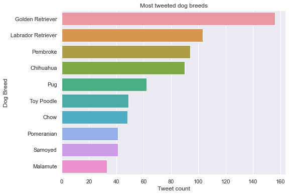

```python
# set background theme
sns.set_theme(style="darkgrid")
plt.style.use('seaborn-pastel')
plt.figure(figsize=(8,6))

# plot the results
sns.barplot(y = 'breed', x = 'count', data = dog_breed);

# set plot properties
plt.title('Most tweeted dog breeds');
plt.xlabel('Tweet count')
plt.ylabel('Dog Breed');

# store the plot
plt.savefig('visualizations/top_breeds.jpg', bbox_inches='tight');
```

- Most tweeted `Dog Breed`: **Golden Retriever**

### Research Question 2: Most tweeted dog stages

```python
# ignore the stages which are 'None'
stage_df = df[(df.dog_stages != 'None')]

# find average dog breed count and select top 10 breeds
dog_stage = stage_df.groupby('dog_stages').agg(count=('dog_stages','count')).reset_index()
dog_stage
```

|  | dog_stages | count |
| --- | --- | --- |
| 0 | doggo | 62 |
| 1 | doggo,floofer | 1 |
| 2 | doggo,pupper | 8 |
| 3 | doggo,puppo | 1 |
| 4 | floofer | 7 |
| 5 | pupper | 201 |
| 6 | puppo | 22 |

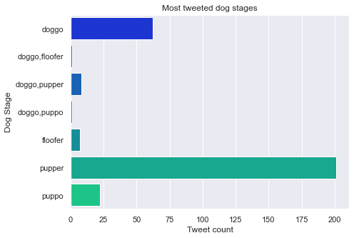

```python
# set figure size
plt.figure(figsize=(7,5))

# plot the results
sns.barplot(x = 'count', y = 'dog_stages', data = dog_stage, palette = ("winter"));

# set plot properties
plt.title('Most tweeted dog stages');
plt.xlabel('Tweet count')
plt.ylabel('Dog Stage');

# store the plot
plt.savefig('visualizations/top_stages.jpg', bbox_inches='tight');
```

- Most tweeted `Dog Stage`: **pupper**

### Research Question 3: Most tweeted dog names

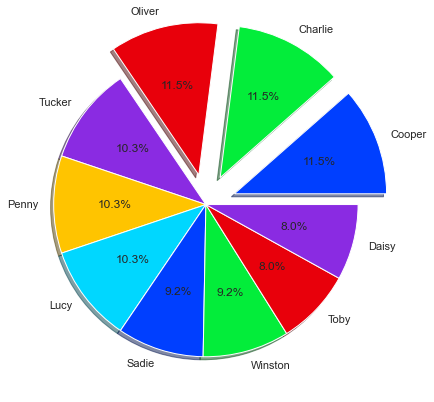

```python
# set plot styple and figure
plt.style.use('seaborn-bright')
plt.figure(figsize=(11, 7))

# ignore the names which is not predicted
name_df = df[df.name != 'None']

# top10 unique name
top_10 = name_df.name.value_counts().nlargest(10)

# plot the results
top_10.plot(kind='pie', label="", autopct='%1.1f%%', explode = [0.2,0.2,0.2,0,0,0,0,0,0,0], shadow=True);

# store the plot
plt.savefig('visualizations/top_names.jpg', bbox_inches='tight');
```

### Research Question 4: Relationship between retweet count and favorite counts

```python
# get the correlation between retweet and favourite count
df[['retweet_count', 'favorite_count']].corr()
```

|  | retweet_count | favorite_count |
| --- | --- | --- |
| retweet_count | 1.000000 | 0.928269 |
| favorite_count | 0.928269 | 1.000000 |

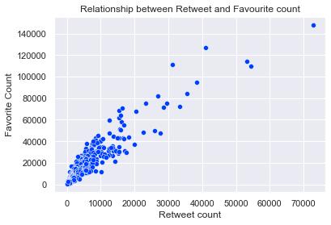

```python
# plot the correlation
sns.scatterplot(x = 'retweet_count', y = 'favorite_count', data = df)

# set plot properties
plt.title('Relationship between Retweet and Favourite count');
plt.xlabel('Retweet count')
plt.ylabel('Favorite Count');

# store the plot
plt.savefig('visualizations/corr_retweet_favo.jpg', bbox_inches='tight');
```

- Retweet and Favourite count has **highly positive relationship (0.928)**

### Research Question 5: Does Ratings associated with retweet count and favorite counts?

```python
# Correlation of movie dataframe
corr = df[['ratings', 'retweet_count', 'favorite_count']].corr()
corr
```

|  | ratings | retweet_count | favorite_count |
| --- | --- | --- | --- |
| ratings | 1.000000 | 0.022416 | 0.021280 |
| retweet_count | 0.022416 | 1.000000 | 0.928269 |
| favorite_count | 0.021280 | 0.928269 | 1.000000 |

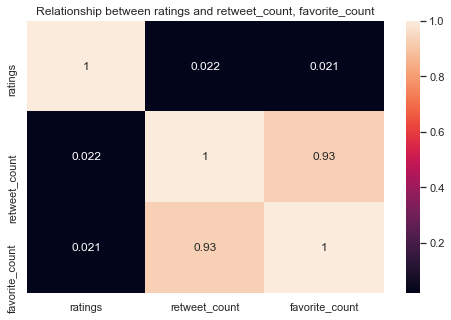

```python
# Set figure size
plt.figure(figsize=(8,5))

# Plot correlation using heapmap
sns.heatmap(df[['ratings', 'retweet_count', 'favorite_count']].corr(), annot=True, cmap='rocket');

# set plot title
plt.title('Relationship between ratings and retweet_count, favorite_count');

# store the plot
plt.savefig('visualizations/corr_rate_retweet_favo.jpg', bbox_inches='tight');
```

### Research Question 6: Which Dog breed received highest rating, retweet and favorite counts?

```python
# find average ratings for dog breeds and select top 10 breeds
ratings_breed  = breed_df.groupby('breed')[['ratings']].mean().reset_index()
ratings_breed = ratings_breed.sort_values(['ratings'], ascending = False).head(10)
ratings_breed
```

|  | breed | ratings |
| --- | --- | --- |
| 24 | Samoyed | 1.173171 |
| 11 | Golden Retriever | 1.155769 |
| 12 | Great Pyrenees | 1.146667 |
| 20 | Pembroke | 1.142553 |
| 6 | Chow | 1.141667 |
| 8 | Eskimo Dog | 1.140909 |
| 7 | Cocker Spaniel | 1.133333 |
| 27 | Siberian Husky | 1.130000 |
| 15 | Labrador Retriever | 1.117476 |
| 9 | French Bulldog | 1.116667 |

```python
# find average retweet and favorite counts for dog breeds and select top 10 breeds
ret_fav_breed  = breed_df.groupby('breed')[['retweet_count','favorite_count']].mean().reset_index()
ret_fav_breed = ret_fav_breed.sort_values(['retweet_count','favorite_count'], ascending = False).head(10)
ret_fav_breed
```

|  | breed | retweet_count | favorite_count |
| --- | --- | --- | --- |
| 9 | French Bulldog | 4530.033333 | 17932.433333 |
| 7 | Cocker Spaniel | 4071.433333 | 12024.266667 |
| 8 | Eskimo Dog | 3988.772727 | 11320.090909 |
| 24 | Samoyed | 3908.560976 | 12027.682927 |
| 12 | Great Pyrenees | 3706.266667 | 10759.666667 |
| 16 | Lakeland Terrier | 3582.411765 | 11038.529412 |
| 11 | Golden Retriever | 3141.493590 | 11057.807692 |
| 3 | Cardigan | 3127.238095 | 11193.380952 |
| 15 | Labrador Retriever | 3113.660194 | 10247.990291 |
| 17 | Malamute | 2756.212121 | 9450.060606 |

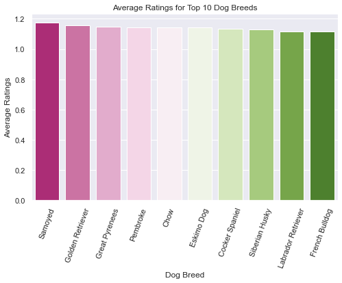

```python
# set figure size
plt.figure(figsize=(8, 5))

# plot the results
sns.barplot(x= 'breed', y ='ratings', data = ratings_breed, palette = "PiYG");

# set plot properties
plt.title('Average Ratings for Top 10 Dog Breeds');
plt.xlabel('Dog Breed')
plt.ylabel('Average Ratings')
plt.xticks(rotation=70);

# store the plot
plt.savefig('visualizations/top_breeds_ratings.jpg', bbox_inches='tight');
```

- Most Rated `Dog Breed`: **Samoyed**

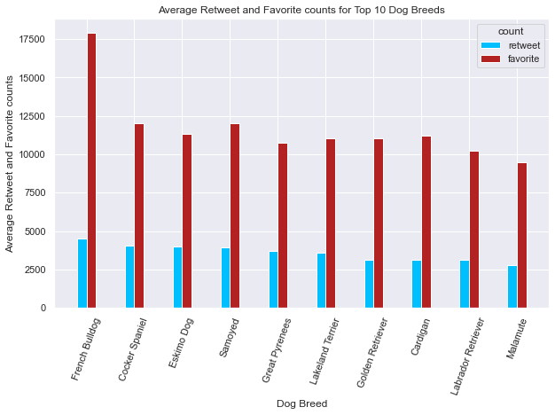

```python
 # set location and labels
ind = np.arange(len(ret_fav_breed))
width=0.2
locations=ind+width/2
labels = ret_fav_breed.breed

# Set figure size
plt.figure(figsize=(10, 6))

#Plot the results
ret_fav_bars = plt.bar(ind, ret_fav_breed.retweet_count, width, label='retweet', color = "deepskyblue")
fav_bars = plt.bar(ind+width, ret_fav_breed.favorite_count, width, label='favorite', color = "firebrick")

# set plot properties
plt.title('Average Retweet and Favorite counts for Top 10 Dog Breeds');
plt.xlabel('Dog Breed')
plt.ylabel('Average Retweet and Favorite counts');
plt.xticks(locations,labels,rotation=70)
plt.legend(title = 'count', loc = 'best');

# store the plot
plt.savefig('visualizations/popular_breeds.jpg', bbox_inches='tight');
```

- Most Retweeted and Favorited `Dog Breed`: **French Bulldog**

### Research Question 7: Which Dog stages received highest rating, retweet and favorite counts?

```python
# ignore the stages which are 'None'
stage_df = df[(df.dog_stages != 'None')]

# unique dog stages count
stg_counts = stage_df.dog_stages.value_counts(ascending=True)
stg_counts
```

```
doggo,floofer      1
doggo,puppo        1
floofer            7
doggo,pupper       8
puppo             22
doggo             62
pupper           201
Name: dog_stages, dtype: int64
```

**Similarly, dog stages also contains outliers. so, Lets remove the outliers**

```python
# take the dog stage which is tweeted altleast 20 times
stage_df = stage_df.loc[df.dog_stages.isin(stg_counts.index[stg_counts > 20])]
stage_df.dog_stages.value_counts()
```

```
pupper    201
doggo      62
puppo      22
Name: dog_stages, dtype: int64
```

```python
# find average ratings for dog stages and select top 10 breeds
ratings_stage  = (stage_df.groupby('dog_stages'))[['ratings']].mean().reset_index()
ratings_stage = ratings_stage.sort_values(['ratings'], ascending = False).head(10)
ratings_stage
```

|  | dog_stages | ratings |
| --- | --- | --- |
| 2 | puppo | 1.200000 |
| 0 | doggo | 1.187097 |
| 1 | pupper | 1.063816 |

```python
# find average retweet and favorite counts for dog stages and select top 10 breeds
ret_fav_stage  = (stage_df.groupby('dog_stages'))[['retweet_count','favorite_count']].mean().reset_index()
ret_fav_stage = ret_fav_stage.sort_values(['retweet_count','favorite_count'], ascending = False).head(10)
ret_fav_stage
```

|  | dog_stages | retweet_count | favorite_count |
| --- | --- | --- | --- |
| 0 | doggo | 6142.548387 | 18006.725806 |
| 2 | puppo | 5473.500000 | 20012.227273 |
| 1 | pupper | 1982.502488 | 6401.084577 |

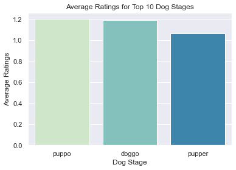

```python
# plot the results
sns.barplot(x= 'dog_stages', y ='ratings', data = ratings_stage, palette = "GnBu");

# set plot properties
plt.title('Average Ratings for Top 10 Dog Stages');
plt.xlabel('Dog Stage')
plt.ylabel('Average Ratings');

# store the plot
plt.savefig('visualizations/top_stages_ratings.jpg', bbox_inches='tight');
```

- Most Rated `Dog Stage`: **puppo**

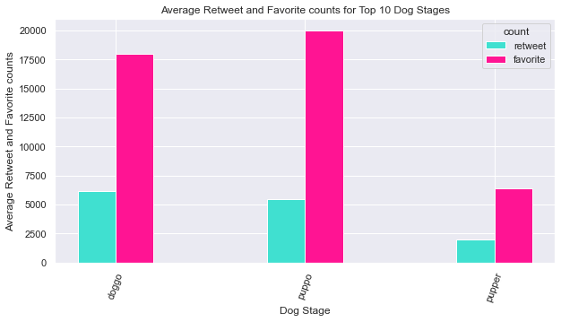

```python
# set location and labels
ind = np.arange(len(ret_fav_stage))
width=0.2
locations=ind+width/2
labels = ret_fav_stage.dog_stages

# Set figure size
plt.figure(figsize=(10, 5))

#Plot the results
ret_fav_bars = plt.bar(ind, ret_fav_stage.retweet_count, width, label='retweet', color = "turquoise")
fav_bars = plt.bar(ind+width, ret_fav_stage.favorite_count, width, label='favorite', color = "deeppink")

# set plot properties
plt.title('Average Retweet and Favorite counts for Top 10 Dog Stages');
plt.xlabel('Dog Stage')
plt.ylabel('Average Retweet and Favorite counts');
plt.xticks(locations,labels,rotation=70)
plt.legend(title = 'count', loc = 'best');

# store the plot
plt.savefig('visualizations/pop_stages.jpg', bbox_inches='tight');
```

- Most Retweeted `Dog Stage`: **doggo**
- Most Favorited `Dog Breed`: **puppo**